# PROJECT BASED INTERN: DATA SCIENTIST

# HOME CREDIT INDONESIA

Maulana Kavaldo | 16 Maret 2023

[Maulana Kavaldo](https://maulanakavaldo.github.io)

[Maulana Kavaldo](https://linkedin.com/in/maulana-kavaldo)

## Goals

Menggali insight dan melakukan prediksi apakah pelanggan akan berhasil atau tidak melakukan pelunasan ketika melakukan pengajuan pinjaman.

## Dataset

Description:

- application_{train|test}.csv
  - This is the main table, broken into two files for Train (with TARGET) and Test (without TARGET).
  - Static data for all applications. One row represents one loan in our data sample.

| No | Row | Description |
| --- | --- | --- |
| 1 | SK_ID_CURR | ID of loan in our sample |
| 2 | TARGET | Target variable (1 - client with payment difficulties: he/she had late payment more than X days on at least one of the first Y installments of the loan in our sample, 0 - all other cases) |
| 5 | NAME_CONTRACT_TYPE | Identification if loan is cash or revolving |
| 6 | CODE_GENDER | Gender of the client |
| 7 | FLAG_OWN_CAR | Flag if the client owns a car |
| 8 | FLAG_OWN_REALTY | Flag if client owns a house or flat |
| 9 | CNT_CHILDREN | Number of children the client has |
| 10 | AMT_INCOME_TOTAL | Income of the client |
| 11 | AMT_CREDIT | Credit amount of the loan |
| 12 | AMT_ANNUITY | Loan annuity |
| 13 | AMT_GOODS_PRICE | For consumer loans it is the price of the goods for which the loan is given |
| 14 | NAME_TYPE_SUITE | Who was accompanying client when he was applying for the loan |
| 15 | NAME_INCOME_TYPE | Clients income type (businessman, working, maternity leave,…) |
| 16 | NAME_EDUCATION_TYPE | Level of highest education the client achieved |
| 17 | NAME_FAMILY_STATUS | Family status of the client |
| 18 | NAME_HOUSING_TYPE | What is the housing situation of the client (renting, living with parents, ...) |
| 19 | REGION_POPULATION_RELATIVE | Normalized population of region where client lives (higher number means the client lives in more populated region) |
| 20 | DAYS_BIRTH | Client's age in days at the time of application |
| 21 | DAYS_EMPLOYED | How many days before the application the person started current employment |
| 22 | DAYS_REGISTRATION | How many days before the application did client change his registration |
| 23 | DAYS_ID_PUBLISH | How many days before the application did client change the identity document with which he applied for the loan |
| 24 | OWN_CAR_AGE | Age of client's car |
| 25 | FLAG_MOBIL | Did client provide mobile phone (1=YES, 0=NO) |
| 26 | FLAG_EMP_PHONE | Did client provide work phone (1=YES, 0=NO) |
| 27 | FLAG_WORK_PHONE | Did client provide home phone (1=YES, 0=NO) |
| 28 | FLAG_CONT_MOBILE | Was mobile phone reachable (1=YES, 0=NO) |
| 29 | FLAG_PHONE | Did client provide home phone (1=YES, 0=NO) |
| 30 | FLAG_EMAIL | Did client provide email (1=YES, 0=NO) |
| 31 | OCCUPATION_TYPE | What kind of occupation does the client have |
| 32 | CNT_FAM_MEMBERS | How many family members does client have |

[output cut: 92 more lines]

## Process Flow

**Langkah-langkah pengerjaan project:**

**1. Data preparation & Preprocessing**: Mengumpulkan dan memanipulasi data untuk menghasilkan informasi.

**2. Exploratory Data Analys**: Melakukan analisis data untuk mendapatkan insight.

**3. Building a model**: Menggunakan model untuk melakukan prediksi.

**4. Testing the model**: Testing pada data baru.

## Step by Step

### Import Library

```python
import os
# For Processing/Manupulation
import numpy as np
import pandas as pd
import matplotlib.pyplot as plt
import plotly.express as px
import seaborn as sns

import warnings
warnings.filterwarnings("ignore")
from sys import displayhook

# For show all inside dataframe
pd.set_option("display.max_columns",None)
pd.set_option("display.max_rows",None)
```

### Function

```python
def get_all_cols(df):
    all_col = list(df.columns)
    return all_col

def get_cat_cols(df):
    cat=list(df.columns[df.dtypes=='object'])
    return cat

def get_num_cols(df):
    num=list(df.columns[df.dtypes=='int64'])+list(df.columns[df.dtypes=='int32'])+list(df.columns[df.dtypes=='float64'])
    return num

def get_head(df):
  print(f'Shape : {df.shape}')
  displayhook(df.head())

def check_missing(df, percentage=0):
    percent=df.isnull().sum()/df.shape[0]*100
    freq=df.isnull().sum()
    types=df.dtypes
    df_miss=pd.DataFrame({'percentage':percent, 'frequency':freq, 'var_type':types})
    df_miss.sort_values(by='frequency',ascending= False, inplace=True)
    # return df_miss[df_miss['percentage']>percentage]
    return df_miss[df_miss['percentage']>percentage]

def get_missing(df):
    null = pd.DataFrame(df.isnull().sum(),columns=["Null Values"])
    null["% Missing Values"] = (df.isna().sum()/len(df)*100)
    null = null[null["% Missing Values"] > 0]
    most_null = null.sort_values('% Missing Values', ascending=False)
    most_null.style.background_gradient(cmap='viridis',low = 0.2,high = 0.1)
    return most_null
```

### Import Dataset

```python
df = pd.read_csv('dataset/application_train.csv')
```

```python
# Memilih kolom
df = df[['TARGET','NAME_CONTRACT_TYPE','CODE_GENDER','DAYS_BIRTH','FLAG_OWN_CAR', 'FLAG_OWN_REALTY',
        'CNT_CHILDREN','AMT_INCOME_TOTAL','AMT_CREDIT','AMT_ANNUITY','AMT_GOODS_PRICE','NAME_TYPE_SUITE',
        'NAME_INCOME_TYPE','NAME_EDUCATION_TYPE','NAME_FAMILY_STATUS','NAME_HOUSING_TYPE','REGION_POPULATION_RELATIVE',
        'OWN_CAR_AGE','FLAG_MOBIL','FLAG_EMP_PHONE','FLAG_WORK_PHONE','FLAG_CONT_MOBILE','FLAG_PHONE','FLAG_EMAIL',
        'OCCUPATION_TYPE','CNT_FAM_MEMBERS','REGION_RATING_CLIENT','REGION_RATING_CLIENT_W_CITY',
        'WEEKDAY_APPR_PROCESS_START','HOUR_APPR_PROCESS_START','REG_REGION_NOT_LIVE_REGION','REG_REGION_NOT_WORK_REGION',
        'LIVE_REGION_NOT_WORK_REGION','ORGANIZATION_TYPE','OBS_30_CNT_SOCIAL_CIRCLE','DEF_30_CNT_SOCIAL_CIRCLE',
        'OBS_60_CNT_SOCIAL_CIRCLE','DEF_60_CNT_SOCIAL_CIRCLE','DAYS_LAST_PHONE_CHANGE','AMT_REQ_CREDIT_BUREAU_HOUR',
        'AMT_REQ_CREDIT_BUREAU_DAY','AMT_REQ_CREDIT_BUREAU_WEEK','AMT_REQ_CREDIT_BUREAU_MON','AMT_REQ_CREDIT_BUREAU_QRT',
        'AMT_REQ_CREDIT_BUREAU_YEAR'
        ]]
```

```python
get_head(df)
```

```
Shape : (307511, 45)
```

|  | TARGET | NAME_CONTRACT_TYPE | CODE_GENDER | DAYS_BIRTH | FLAG_OWN_CAR | FLAG_OWN_REALTY | CNT_CHILDREN | AMT_INCOME_TOTAL | AMT_CREDIT | AMT_ANNUITY | AMT_GOODS_PRICE | NAME_TYPE_SUITE | NAME_INCOME_TYPE | NAME_EDUCATION_TYPE | NAME_FAMILY_STATUS | NAME_HOUSING_TYPE | REGION_POPULATION_RELATIVE | OWN_CAR_AGE | FLAG_MOBIL | FLAG_EMP_PHONE | FLAG_WORK_PHONE | FLAG_CONT_MOBILE | FLAG_PHONE | FLAG_EMAIL | OCCUPATION_TYPE | CNT_FAM_MEMBERS | REGION_RATING_CLIENT | REGION_RATING_CLIENT_W_CITY | WEEKDAY_APPR_PROCESS_START | … |
| --- | --- | --- | --- | --- | --- | --- | --- | --- | --- | --- | --- | --- | --- | --- | --- | --- | --- | --- | --- | --- | --- | --- | --- | --- | --- | --- | --- | --- | --- | --- |
| 0 | 1 | Cash loans | M | -9461 | N | Y | 0 | 202500.0 | 406597.5 | 24700.5 | 351000.0 | Unaccompanied | Working | Secondary / secondary special | Single / not married | House / apartment | 0.018801 | NaN | 1 | 1 | 0 | 1 | 1 | 0 | Laborers | 1.0 | 2 | 2 | WEDNESDAY | … |
| 1 | 0 | Cash loans | F | -16765 | N | N | 0 | 270000.0 | 1293502.5 | 35698.5 | 1129500.0 | Family | State servant | Higher education | Married | House / apartment | 0.003541 | NaN | 1 | 1 | 0 | 1 | 1 | 0 | Core staff | 2.0 | 1 | 1 | MONDAY | … |
| 2 | 0 | Revolving loans | M | -19046 | Y | Y | 0 | 67500.0 | 135000.0 | 6750.0 | 135000.0 | Unaccompanied | Working | Secondary / secondary special | Single / not married | House / apartment | 0.010032 | 26.0 | 1 | 1 | 1 | 1 | 1 | 0 | Laborers | 1.0 | 2 | 2 | MONDAY | … |
| 3 | 0 | Cash loans | F | -19005 | N | Y | 0 | 135000.0 | 312682.5 | 29686.5 | 297000.0 | Unaccompanied | Working | Secondary / secondary special | Civil marriage | House / apartment | 0.008019 | NaN | 1 | 1 | 0 | 1 | 0 | 0 | Laborers | 2.0 | 2 | 2 | WEDNESDAY | … |
| 4 | 0 | Cash loans | M | -19932 | N | Y | 0 | 121500.0 | 513000.0 | 21865.5 | 513000.0 | Unaccompanied | Working | Secondary / secondary special | Single / not married | House / apartment | 0.028663 | NaN | 1 | 1 | 0 | 1 | 0 | 0 | Core staff | 1.0 | 2 | 2 | THURSDAY | … |

```python
df.info()
```

```
<class 'pandas.core.frame.DataFrame'>
RangeIndex: 307511 entries, 0 to 307510
Data columns (total 45 columns):
 #   Column                       Non-Null Count   Dtype
---  ------                       --------------   -----
 0   TARGET                       307511 non-null  int64
 1   NAME_CONTRACT_TYPE           307511 non-null  object
 2   CODE_GENDER                  307511 non-null  object
 3   DAYS_BIRTH                   307511 non-null  int64
 4   FLAG_OWN_CAR                 307511 non-null  object
 5   FLAG_OWN_REALTY              307511 non-null  object
 6   CNT_CHILDREN                 307511 non-null  int64
 7   AMT_INCOME_TOTAL             307511 non-null  float64
 8   AMT_CREDIT                   307511 non-null  float64
 9   AMT_ANNUITY                  307499 non-null  float64
```

[output cut: 37 more lines]

### Descriptive Statistics

```python
df.describe()
```

|  | TARGET | DAYS_BIRTH | CNT_CHILDREN | AMT_INCOME_TOTAL | AMT_CREDIT | AMT_ANNUITY | AMT_GOODS_PRICE | REGION_POPULATION_RELATIVE | OWN_CAR_AGE | FLAG_MOBIL | FLAG_EMP_PHONE | FLAG_WORK_PHONE | FLAG_CONT_MOBILE | FLAG_PHONE | FLAG_EMAIL | CNT_FAM_MEMBERS | REGION_RATING_CLIENT | REGION_RATING_CLIENT_W_CITY | HOUR_APPR_PROCESS_START | REG_REGION_NOT_LIVE_REGION | REG_REGION_NOT_WORK_REGION | LIVE_REGION_NOT_WORK_REGION | OBS_30_CNT_SOCIAL_CIRCLE | DEF_30_CNT_SOCIAL_CIRCLE | OBS_60_CNT_SOCIAL_CIRCLE | DEF_60_CNT_SOCIAL_CIRCLE | DAYS_LAST_PHONE_CHANGE | AMT_REQ_CREDIT_BUREAU_HOUR | AMT_REQ_CREDIT_BUREAU_DAY | … |
| --- | --- | --- | --- | --- | --- | --- | --- | --- | --- | --- | --- | --- | --- | --- | --- | --- | --- | --- | --- | --- | --- | --- | --- | --- | --- | --- | --- | --- | --- | --- |
| count | 307511.000000 | 307511.000000 | 307511.000000 | 3.075110e+05 | 3.075110e+05 | 307499.000000 | 3.072330e+05 | 307511.000000 | 104582.000000 | 307511.000000 | 307511.000000 | 307511.000000 | 307511.000000 | 307511.000000 | 307511.000000 | 307509.000000 | 307511.000000 | 307511.000000 | 307511.000000 | 307511.000000 | 307511.000000 | 307511.000000 | 306490.000000 | 306490.000000 | 306490.000000 | 306490.000000 | 307510.000000 | 265992.000000 | 265992.000000 | … |
| mean | 0.080729 | -16036.995067 | 0.417052 | 1.687979e+05 | 5.990260e+05 | 27108.573909 | 5.383962e+05 | 0.020868 | 12.061091 | 0.999997 | 0.819889 | 0.199368 | 0.998133 | 0.281066 | 0.056720 | 2.152665 | 2.052463 | 2.031521 | 12.063419 | 0.015144 | 0.050769 | 0.040659 | 1.422245 | 0.143421 | 1.405292 | 0.100049 | -962.858788 | 0.006402 | 0.007000 | … |
| std | 0.272419 | 4363.988632 | 0.722121 | 2.371231e+05 | 4.024908e+05 | 14493.737315 | 3.694465e+05 | 0.013831 | 11.944812 | 0.001803 | 0.384280 | 0.399526 | 0.043164 | 0.449521 | 0.231307 | 0.910682 | 0.509034 | 0.502737 | 3.265832 | 0.122126 | 0.219526 | 0.197499 | 2.400989 | 0.446698 | 2.379803 | 0.362291 | 826.808487 | 0.083849 | 0.110757 | … |
| min | 0.000000 | -25229.000000 | 0.000000 | 2.565000e+04 | 4.500000e+04 | 1615.500000 | 4.050000e+04 | 0.000290 | 0.000000 | 0.000000 | 0.000000 | 0.000000 | 0.000000 | 0.000000 | 0.000000 | 1.000000 | 1.000000 | 1.000000 | 0.000000 | 0.000000 | 0.000000 | 0.000000 | 0.000000 | 0.000000 | 0.000000 | 0.000000 | -4292.000000 | 0.000000 | 0.000000 | … |
| 25% | 0.000000 | -19682.000000 | 0.000000 | 1.125000e+05 | 2.700000e+05 | 16524.000000 | 2.385000e+05 | 0.010006 | 5.000000 | 1.000000 | 1.000000 | 0.000000 | 1.000000 | 0.000000 | 0.000000 | 2.000000 | 2.000000 | 2.000000 | 10.000000 | 0.000000 | 0.000000 | 0.000000 | 0.000000 | 0.000000 | 0.000000 | 0.000000 | -1570.000000 | 0.000000 | 0.000000 | … |
| 50% | 0.000000 | -15750.000000 | 0.000000 | 1.471500e+05 | 5.135310e+05 | 24903.000000 | 4.500000e+05 | 0.018850 | 9.000000 | 1.000000 | 1.000000 | 0.000000 | 1.000000 | 0.000000 | 0.000000 | 2.000000 | 2.000000 | 2.000000 | 12.000000 | 0.000000 | 0.000000 | 0.000000 | 0.000000 | 0.000000 | 0.000000 | 0.000000 | -757.000000 | 0.000000 | 0.000000 | … |
| 75% | 0.000000 | -12413.000000 | 1.000000 | 2.025000e+05 | 8.086500e+05 | 34596.000000 | 6.795000e+05 | 0.028663 | 15.000000 | 1.000000 | 1.000000 | 0.000000 | 1.000000 | 1.000000 | 0.000000 | 3.000000 | 2.000000 | 2.000000 | 14.000000 | 0.000000 | 0.000000 | 0.000000 | 2.000000 | 0.000000 | 2.000000 | 0.000000 | -274.000000 | 0.000000 | 0.000000 | … |
| max | 1.000000 | -7489.000000 | 19.000000 | 1.170000e+08 | 4.050000e+06 | 258025.500000 | 4.050000e+06 | 0.072508 | 91.000000 | 1.000000 | 1.000000 | 1.000000 | 1.000000 | 1.000000 | 1.000000 | 20.000000 | 3.000000 | 3.000000 | 23.000000 | 1.000000 | 1.000000 | 1.000000 | 348.000000 | 34.000000 | 344.000000 | 24.000000 | 0.000000 | 4.000000 | 9.000000 | … |

```python
df.describe(include ='O').T.sort_values(by='unique')
```

|  | count | unique | top | freq |
| --- | --- | --- | --- | --- |
| NAME_CONTRACT_TYPE | 307511 | 2 | Cash loans | 278232 |
| FLAG_OWN_CAR | 307511 | 2 | N | 202924 |
| FLAG_OWN_REALTY | 307511 | 2 | Y | 213312 |
| CODE_GENDER | 307511 | 3 | F | 202448 |
| NAME_EDUCATION_TYPE | 307511 | 5 | Secondary / secondary special | 218391 |
| NAME_FAMILY_STATUS | 307511 | 6 | Married | 196432 |
| NAME_HOUSING_TYPE | 307511 | 6 | House / apartment | 272868 |
| NAME_TYPE_SUITE | 306219 | 7 | Unaccompanied | 248526 |
| WEEKDAY_APPR_PROCESS_START | 307511 | 7 | TUESDAY | 53901 |
| NAME_INCOME_TYPE | 307511 | 8 | Working | 158774 |
| OCCUPATION_TYPE | 211120 | 18 | Laborers | 55186 |
| ORGANIZATION_TYPE | 307511 | 58 | Business Entity Type 3 | 67992 |

```python
df_obj = pd.DataFrame(df.select_dtypes('object').nunique()).reset_index()
df_obj.columns = ['Column','N Unique Values']

## ekstrak unique value
df_obj['Unique Values'] = df_obj['Column'].apply(lambda x: df[x].unique())
df_obj.sort_values(by='N Unique Values')
```

|  | Column | N Unique Values | Unique Values |
| --- | --- | --- | --- |
| 0 | NAME_CONTRACT_TYPE | 2 | [Cash loans, Revolving loans] |
| 2 | FLAG_OWN_CAR | 2 | [N, Y] |
| 3 | FLAG_OWN_REALTY | 2 | [Y, N] |
| 1 | CODE_GENDER | 3 | [M, F, XNA] |
| 6 | NAME_EDUCATION_TYPE | 5 | [Secondary / secondary special, Higher educati... |
| 7 | NAME_FAMILY_STATUS | 6 | [Single / not married, Married, Civil marriage... |
| 8 | NAME_HOUSING_TYPE | 6 | [House / apartment, Rented apartment, With par... |
| 4 | NAME_TYPE_SUITE | 7 | [Unaccompanied, Family, Spouse, partner, Child... |
| 10 | WEEKDAY_APPR_PROCESS_START | 7 | [WEDNESDAY, MONDAY, THURSDAY, SUNDAY, SATURDAY... |
| 5 | NAME_INCOME_TYPE | 8 | [Working, State servant, Commercial associate,... |
| 9 | OCCUPATION_TYPE | 18 | [Laborers, Core staff, Accountants, Managers, ... |
| 11 | ORGANIZATION_TYPE | 58 | [Business Entity Type 3, School, Government, R... |

**Insight:**

[figure not shown]

Pada kolom Gender: Terdapat customers dengan jenis kelamin selain pria atau wanita, sebut saja transgender. Bukan merupakan data kosong.

```python
# Unique value for categorical columns
for col in df.select_dtypes('object'):
    print(df[col].unique().tolist())
```

```
['Cash loans', 'Revolving loans']
['M', 'F', 'XNA']
['N', 'Y']
['Y', 'N']
['Unaccompanied', 'Family', 'Spouse, partner', 'Children', 'Other_A', nan, 'Other_B', 'Group of people']
['Working', 'State servant', 'Commercial associate', 'Pensioner', 'Unemployed', 'Student', 'Businessman', 'Maternity leave']
['Secondary / secondary special', 'Higher education', 'Incomplete higher', 'Lower secondary', 'Academic degree']
['Single / not married', 'Married', 'Civil marriage', 'Widow', 'Separated', 'Unknown']
['House / apartment', 'Rented apartment', 'With parents', 'Municipal apartment', 'Office apartment', 'Co-op apartment']
['Laborers', 'Core staff', 'Accountants', 'Managers', nan, 'Drivers', 'Sales staff', 'Cleaning staff', 'Cooking staff', 'Private service staff', 'Medicine staff', 'Security staff', 'High skill tech staff', 'Waiters/barmen staff', 'Low-skill Laborers', 'Realty agents', 'Secretaries', 'IT staff', 'HR …
['WEDNESDAY', 'MONDAY', 'THURSDAY', 'SUNDAY', 'SATURDAY', 'FRIDAY', 'TUESDAY']
['Business Entity Type 3', 'School', 'Government', 'Religion', 'Other', 'XNA', 'Electricity', 'Medicine', 'Business Entity Type 2', 'Self-employed', 'Transport: type 2', 'Construction', 'Housing', 'Kindergarten', 'Trade: type 7', 'Industry: type 11', 'Military', 'Services', 'Security Ministries', 'T…
```

### Data Quality Checking

Missing Values

```python
check_missing(df)
```

|  | percentage | frequency | var_type |
| --- | --- | --- | --- |
| OWN_CAR_AGE | 65.990810 | 202929 | float64 |
| OCCUPATION_TYPE | 31.345545 | 96391 | object |
| AMT_REQ_CREDIT_BUREAU_DAY | 13.501631 | 41519 | float64 |
| AMT_REQ_CREDIT_BUREAU_HOUR | 13.501631 | 41519 | float64 |
| AMT_REQ_CREDIT_BUREAU_YEAR | 13.501631 | 41519 | float64 |
| AMT_REQ_CREDIT_BUREAU_WEEK | 13.501631 | 41519 | float64 |
| AMT_REQ_CREDIT_BUREAU_QRT | 13.501631 | 41519 | float64 |
| AMT_REQ_CREDIT_BUREAU_MON | 13.501631 | 41519 | float64 |
| NAME_TYPE_SUITE | 0.420148 | 1292 | object |
| OBS_30_CNT_SOCIAL_CIRCLE | 0.332021 | 1021 | float64 |
| DEF_30_CNT_SOCIAL_CIRCLE | 0.332021 | 1021 | float64 |
| OBS_60_CNT_SOCIAL_CIRCLE | 0.332021 | 1021 | float64 |
| DEF_60_CNT_SOCIAL_CIRCLE | 0.332021 | 1021 | float64 |
| AMT_GOODS_PRICE | 0.090403 | 278 | float64 |
| AMT_ANNUITY | 0.003902 | 12 | float64 |
| CNT_FAM_MEMBERS | 0.000650 | 2 | float64 |
| DAYS_LAST_PHONE_CHANGE | 0.000325 | 1 | float64 |

```python
# Handling missing value
for i in df.columns:
    data = df[i]
    types = str(data.dtype)
    if types == 'object':
        df[i].fillna(df[i].mode()[0], inplace=True)
    else:
        df[i].fillna(df[i].median(), inplace=True)
```

```python
check_missing(df)
```

|  | percentage | frequency | var_type |
| --- | --- | --- | --- |

Duplicate Values

```python
#check duplicate train

duplicate = df[df.duplicated()]
print("Shape:", duplicate.shape)
duplicate
```

```
Shape: (11, 45)
```

|  | TARGET | NAME_CONTRACT_TYPE | CODE_GENDER | DAYS_BIRTH | FLAG_OWN_CAR | FLAG_OWN_REALTY | CNT_CHILDREN | AMT_INCOME_TOTAL | AMT_CREDIT | AMT_ANNUITY | AMT_GOODS_PRICE | NAME_TYPE_SUITE | NAME_INCOME_TYPE | NAME_EDUCATION_TYPE | NAME_FAMILY_STATUS | NAME_HOUSING_TYPE | REGION_POPULATION_RELATIVE | OWN_CAR_AGE | FLAG_MOBIL | FLAG_EMP_PHONE | FLAG_WORK_PHONE | FLAG_CONT_MOBILE | FLAG_PHONE | FLAG_EMAIL | OCCUPATION_TYPE | CNT_FAM_MEMBERS | REGION_RATING_CLIENT | REGION_RATING_CLIENT_W_CITY | WEEKDAY_APPR_PROCESS_START | … |
| --- | --- | --- | --- | --- | --- | --- | --- | --- | --- | --- | --- | --- | --- | --- | --- | --- | --- | --- | --- | --- | --- | --- | --- | --- | --- | --- | --- | --- | --- | --- |
| 29287 | 0 | Cash loans | M | -24161 | Y | N | 0 | 112500.0 | 269550.0 | 11547.0 | 225000.0 | Unaccompanied | Pensioner | Secondary / secondary special | Married | House / apartment | 0.025164 | 14.0 | 1 | 0 | 0 | 1 | 0 | 0 | Laborers | 2.0 | 2 | 2 | TUESDAY | … |
| 82410 | 0 | Cash loans | M | -13245 | Y | Y | 2 | 360000.0 | 450000.0 | 47880.0 | 450000.0 | Unaccompanied | Working | Higher education | Married | House / apartment | 0.026392 | 3.0 | 1 | 1 | 0 | 1 | 0 | 0 | Managers | 4.0 | 2 | 2 | FRIDAY | … |
| 83790 | 0 | Cash loans | F | -24223 | N | Y | 0 | 157500.0 | 284400.0 | 15880.5 | 225000.0 | Unaccompanied | State servant | Secondary / secondary special | Married | House / apartment | 0.072508 | 9.0 | 1 | 1 | 0 | 1 | 1 | 0 | Medicine staff | 2.0 | 1 | 1 | FRIDAY | … |
| 127310 | 0 | Cash loans | M | -9597 | Y | N | 0 | 202500.0 | 482530.5 | 26176.5 | 482530.5 | Unaccompanied | State servant | Higher education | Single / not married | With parents | 0.026392 | 64.0 | 1 | 1 | 0 | 1 | 0 | 0 | Core staff | 1.0 | 2 | 2 | WEDNESDAY | … |
| 131412 | 0 | Cash loans | F | -24784 | N | Y | 0 | 81000.0 | 239850.0 | 23494.5 | 225000.0 | Unaccompanied | Pensioner | Higher education | Married | House / apartment | 0.007114 | 9.0 | 1 | 0 | 0 | 1 | 0 | 0 | Laborers | 2.0 | 2 | 2 | TUESDAY | … |
| 171859 | 0 | Cash loans | F | -24813 | N | Y | 0 | 117000.0 | 254700.0 | 24939.0 | 225000.0 | Family | Pensioner | Secondary / secondary special | Married | House / apartment | 0.030755 | 9.0 | 1 | 0 | 0 | 1 | 0 | 0 | Laborers | 2.0 | 2 | 2 | THURSDAY | … |
| 172053 | 0 | Cash loans | F | -24475 | N | Y | 0 | 126000.0 | 284400.0 | 16011.0 | 225000.0 | Unaccompanied | Pensioner | Secondary / secondary special | Widow | House / apartment | 0.035792 | 9.0 | 1 | 0 | 0 | 1 | 0 | 0 | Laborers | 1.0 | 2 | 2 | THURSDAY | … |
| 261724 | 0 | Cash loans | F | -8433 | N | Y | 1 | 112500.0 | 225000.0 | 11074.5 | 225000.0 | Unaccompanied | Working | Incomplete higher | Civil marriage | House / apartment | 0.026392 | 9.0 | 1 | 1 | 0 | 1 | 0 | 0 | Waiters/barmen staff | 3.0 | 2 | 2 | THURSDAY | … |
| 297684 | 1 | Cash loans | M | -15145 | Y | Y | 0 | 180000.0 | 592560.0 | 31153.5 | 450000.0 | Unaccompanied | Commercial associate | Higher education | Married | House / apartment | 0.007020 | 6.0 | 1 | 1 | 0 | 1 | 0 | 0 | Drivers | 2.0 | 2 | 2 | FRIDAY | … |
| 302204 | 0 | Cash loans | F | -24455 | Y | N | 0 | 90000.0 | 254700.0 | 14350.5 | 225000.0 | Unaccompanied | Pensioner | Secondary / secondary special | Single / not married | House / apartment | 0.007120 | 19.0 | 1 | 0 | 0 | 1 | 0 | 0 | Laborers | 1.0 | 2 | 2 | THURSDAY | … |
| 303911 | 0 | Cash loans | M | -24624 | N | Y | 0 | 135000.0 | 254700.0 | 14350.5 | 225000.0 | Unaccompanied | Pensioner | Secondary / secondary special | Single / not married | House / apartment | 0.007120 | 9.0 | 1 | 0 | 0 | 1 | 0 | 0 | Laborers | 1.0 | 2 | 2 | TUESDAY | … |

**Terdapat data duplicate**

Drop Duplicates

```python
df.drop_duplicates(inplace=True)
print(df.duplicated().sum())
```

```
0
```

### Target Variable Distribution

Target:

- 1 : klien dengan kesulitan pembayaran -> terlambat membayar > X hari pada setidaknya satu dari angsuran Y pertama dari pinjaman dalam sampel.
- 0 : Kasus lainnya.

```python
# define target variable
target_variable = 'TARGET'
```

```
(307500, 45)
[282676, 24824]
```

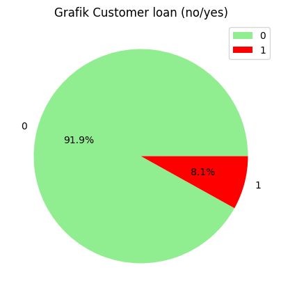

```python
labels = df[target_variable].value_counts().keys().tolist()
values = df[target_variable].value_counts().values.tolist()
print(df.shape)
print(values)
fig1, ax1 = plt.subplots(figsize=(5,5))
ax1.pie(values,
        labels=labels,
#         explode=(0,0.1),
        autopct='%1.1f%%',
        colors=['lightgreen', 'red'])
plt.legend()
plt.title('Grafik Customer loan (no/yes)')
plt.show()
```

**Insight:**

[figure not shown]

**Data sangat tidak seimbang *(imbalanced).***

91.9% dari applicant tidak mengalami kesulitan dalam pembayaran tagihan pinjaman.

```python
ms_acc = df[df['TARGET'] == 0].groupby(['NAME_FAMILY_STATUS'])['CODE_GENDER'].count().reset_index()
ms_acc.rename(columns = {'CODE_GENDER' : 'Customers'}, inplace=True)

ms_acc.sort_values(by='Customers', ascending=False)
```

|  | NAME_FAMILY_STATUS | Customers |
| --- | --- | --- |
| 1 | Married | 181577 |
| 3 | Single / not married | 40984 |
| 0 | Civil marriage | 26813 |
| 2 | Separated | 18150 |
| 5 | Widow | 15150 |
| 4 | Unknown | 2 |

Contract Type

```python
ct = df.groupby(['TARGET', 'NAME_CONTRACT_TYPE'])['CODE_GENDER'].count().reset_index().sort_values(by = 'NAME_CONTRACT_TYPE')
ct.rename(columns = {'CODE_GENDER' : 'Customers'}, inplace=True)

name_of_ct = list(ct['NAME_CONTRACT_TYPE'].unique())
percentage = []

for i in name_of_ct:
    data = ct[ct['NAME_CONTRACT_TYPE'] == i]
    total = data['Customers'].sum()
    for x,y in enumerate(data['Customers']):
        pct = round(y / total, 2)
        percentage.append(pct)

ct['Percent'] = percentage
ct
```

|  | TARGET | NAME_CONTRACT_TYPE | Customers | Percent |
| --- | --- | --- | --- | --- |
| 0 | 0 | Cash loans | 255001 | 0.92 |
| 2 | 1 | Cash loans | 23220 | 0.08 |
| 1 | 0 | Revolving loans | 27675 | 0.95 |
| 3 | 1 | Revolving loans | 1604 | 0.05 |

Occupation Type

```python
ot = df.groupby(['TARGET', 'OCCUPATION_TYPE'])['CODE_GENDER'].count().reset_index().sort_values(by=['OCCUPATION_TYPE', 'TARGET'])
ot.rename(columns = {'CODE_GENDER' : 'Customers'}, inplace=True)

name_of_ot = list(ot['OCCUPATION_TYPE'].unique())
percentage = []

for i in name_of_ot:
    data = ot[ot['OCCUPATION_TYPE'] == i]
    total = data['Customers'].sum()
    for x,y in enumerate(data['Customers']):
        pct = round(y / total, 2)
        percentage.append(pct)

ot['percentage'] = percentage
ot
```

|  | TARGET | OCCUPATION_TYPE | Customers | percentage |
| --- | --- | --- | --- | --- |
| 0 | 0 | Accountants | 9339 | 0.95 |
| 18 | 1 | Accountants | 474 | 0.05 |
| 1 | 0 | Cleaning staff | 4206 | 0.90 |
| 19 | 1 | Cleaning staff | 447 | 0.10 |
| 2 | 0 | Cooking staff | 5325 | 0.90 |
| 20 | 1 | Cooking staff | 621 | 0.10 |
| 3 | 0 | Core staff | 25831 | 0.94 |
| 21 | 1 | Core staff | 1738 | 0.06 |
| 4 | 0 | Drivers | 16496 | 0.89 |
| 22 | 1 | Drivers | 2106 | 0.11 |
| 5 | 0 | HR staff | 527 | 0.94 |
| 23 | 1 | HR staff | 36 | 0.06 |
| 6 | 0 | High skill tech staff | 10679 | 0.94 |
| 24 | 1 | High skill tech staff | 701 | 0.06 |
| 7 | 0 | IT staff | 492 | 0.94 |
| 25 | 1 | IT staff | 34 | 0.06 |
| 8 | 0 | Laborers | 139455 | 0.92 |
| 26 | 1 | Laborers | 12116 | 0.08 |
| 9 | 0 | Low-skill Laborers | 1734 | 0.83 |
| 27 | 1 | Low-skill Laborers | 359 | 0.17 |
| 10 | 0 | Managers | 20042 | 0.94 |
| 28 | 1 | Managers | 1328 | 0.06 |
| 11 | 0 | Medicine staff | 7964 | 0.93 |
| 29 | 1 | Medicine staff | 572 | 0.07 |
| 12 | 0 | Private service staff | 2477 | 0.93 |
| 30 | 1 | Private service staff | 175 | 0.07 |
| 13 | 0 | Realty agents | 692 | 0.92 |
| 31 | 1 | Realty agents | 59 | 0.08 |
| 14 | 0 | Sales staff | 29010 | 0.90 |
| 32 | 1 | Sales staff | 3092 | 0.10 |
| 15 | 0 | Secretaries | 1213 | 0.93 |
| 33 | 1 | Secretaries | 92 | 0.07 |
| 16 | 0 | Security staff | 5999 | 0.89 |
| 34 | 1 | Security staff | 722 | 0.11 |
| 17 | 0 | Waiters/barmen staff | 1195 | 0.89 |
| 35 | 1 | Waiters/barmen staff | 152 | 0.11 |

Age of the customer

Pada dataset tidak terdapat kolom age (umur dari applicant), sehingga membuat kolom baru untuk umur peminjam.

```python
df['Age'] = np.floor(df['DAYS_BIRTH'] / -365).astype(int)
df.drop(columns= 'DAYS_BIRTH', inplace=True)
```

```python
# Mendefinisakan categori umur applicant

age_cat = []
for i in df['Age']:
    if i < 36:
        age_cat.append('Young Adult')
    elif i < 51:
        age_cat.append('Adult')
    else:
        age_cat.append('Older')

df['Age_category'] = age_cat
```

```python
g_age = df.groupby(['TARGET', 'Age_category'])['CODE_GENDER'].count().reset_index().sort_values('Age_category').reset_index()
g_age.rename(columns = {'CODE_GENDER' : 'Customers'}, inplace=True)
g_age.drop(columns = 'index', inplace=True)

name_of_ot = list(g_age['Age_category'].unique())
percentage = []

for i in name_of_ot:
    data = g_age[g_age['Age_category'] == i]
    total = data['Customers'].sum()
    for x,y in enumerate(data['Customers']):
        pct = round(y / total, 2)
        percentage.append(pct)

g_age['percentage'] = percentage

mapping_target = {
    1 : 'Have Problem',
    0 : 'Dont Have Problem'
}

g_age['TARGET'] = g_age['TARGET'].map(mapping_target)
g_age.sort_values(by='Customers', ascending=False)
```

|  | TARGET | Age_category | Customers | percentage |
| --- | --- | --- | --- | --- |
| 0 | Dont Have Problem | Adult | 108677 | 0.92 |
| 2 | Dont Have Problem | Older | 91711 | 0.94 |
| 4 | Dont Have Problem | Young Adult | 82288 | 0.89 |
| 5 | Have Problem | Young Adult | 9953 | 0.11 |
| 1 | Have Problem | Adult | 9402 | 0.08 |
| 3 | Have Problem | Older | 5469 | 0.06 |

```python
fig = px.histogram(g_age, x='Age_category', y='Customers', width=500, height=400, color=target_variable, barmode="group")
fig.show()
```

Income Type of consumer

```python
itc = df.groupby(['TARGET', 'NAME_INCOME_TYPE', 'NAME_CONTRACT_TYPE'])['CODE_GENDER'].count().reset_index().sort_values(['NAME_INCOME_TYPE', 'NAME_CONTRACT_TYPE']).reset_index()
itc.rename(columns = {'CODE_GENDER' : 'Customers'}, inplace=True)
itc.drop(columns = 'index', inplace=True)

income_type   = list(itc['NAME_INCOME_TYPE'].unique())
percentage  = []

for i in income_type:
    data = itc[itc.NAME_INCOME_TYPE == i]
    contract_type = list(data['NAME_CONTRACT_TYPE'].unique())
    for x in contract_type:
        data2 = data[data.NAME_CONTRACT_TYPE == x]
        total = data2['Customers'].sum()
        for y,z in enumerate(data2['Customers']):
            pct = round(z / total, 2)
            percentage.append(pct)

itc['percentage'] = percentage
itc
```

|  | TARGET | NAME_INCOME_TYPE | NAME_CONTRACT_TYPE | Customers | percentage |
| --- | --- | --- | --- | --- | --- |
| 0 | 0 | Businessman | Revolving loans | 10 | 1.00 |
| 1 | 0 | Commercial associate | Cash loans | 58662 | 0.92 |
| 2 | 1 | Commercial associate | Cash loans | 4989 | 0.08 |
| 3 | 0 | Commercial associate | Revolving loans | 7595 | 0.95 |
| 4 | 1 | Commercial associate | Revolving loans | 370 | 0.05 |
| 5 | 1 | Maternity leave | Cash loans | 2 | 1.00 |
| 6 | 0 | Maternity leave | Revolving loans | 3 | 1.00 |
| 7 | 0 | Pensioner | Cash loans | 49145 | 0.95 |
| 8 | 1 | Pensioner | Cash loans | 2842 | 0.05 |
| 9 | 0 | Pensioner | Revolving loans | 3229 | 0.96 |
| 10 | 1 | Pensioner | Revolving loans | 140 | 0.04 |
| 11 | 0 | State servant | Cash loans | 18646 | 0.94 |
| 12 | 1 | State servant | Cash loans | 1188 | 0.06 |
| 13 | 0 | State servant | Revolving loans | 1806 | 0.97 |
| 14 | 1 | State servant | Revolving loans | 61 | 0.03 |
| 15 | 0 | Student | Cash loans | 15 | 1.00 |
| 16 | 0 | Student | Revolving loans | 3 | 1.00 |
| 17 | 0 | Unemployed | Cash loans | 7 | 0.47 |
| 18 | 1 | Unemployed | Cash loans | 8 | 0.53 |
| 19 | 0 | Unemployed | Revolving loans | 7 | 1.00 |
| 20 | 0 | Working | Cash loans | 128526 | 0.90 |
| 21 | 1 | Working | Cash loans | 14191 | 0.10 |
| 22 | 0 | Working | Revolving loans | 15022 | 0.94 |
| 23 | 1 | Working | Revolving loans | 1033 | 0.06 |

```python
fig = px.histogram(itc, x='NAME_INCOME_TYPE', y='Customers', width=500, height=400, color=target_variable, barmode="group")
fig.show()
```

```python
df.drop(columns= ['Age', 'Age_category'], inplace=True)
```

### Numerical Feature Distribution

```python
nums = get_num_cols(df)
```

```python
nums
```

```
['TARGET',
 'CNT_CHILDREN',
 'FLAG_MOBIL',
 'FLAG_EMP_PHONE',
 'FLAG_WORK_PHONE',
 'FLAG_CONT_MOBILE',
 'FLAG_PHONE',
 'FLAG_EMAIL',
 'REGION_RATING_CLIENT',
 'REGION_RATING_CLIENT_W_CITY',
 'HOUR_APPR_PROCESS_START',
 'REG_REGION_NOT_LIVE_REGION',
 'REG_REGION_NOT_WORK_REGION',
 'LIVE_REGION_NOT_WORK_REGION',
 'AMT_INCOME_TOTAL',
 'AMT_CREDIT',
 'AMT_ANNUITY',
 'AMT_GOODS_PRICE',
 'REGION_POPULATION_RELATIVE',
 'OWN_CAR_AGE',
 'CNT_FAM_MEMBERS',
 'OBS_30_CNT_SOCIAL_CIRCLE',
 'DEF_30_CNT_SOCIAL_CIRCLE',
 'OBS_60_CNT_SOCIAL_CIRCLE',
 'DEF_60_CNT_SOCIAL_CIRCLE',
 'DAYS_LAST_PHONE_CHANGE',
 'AMT_REQ_CREDIT_BUREAU_HOUR',
 'AMT_REQ_CREDIT_BUREAU_DAY',
 'AMT_REQ_CREDIT_BUREAU_WEEK',
 'AMT_REQ_CREDIT_BUREAU_MON',
 'AMT_REQ_CREDIT_BUREAU_QRT',
 'AMT_REQ_CREDIT_BUREAU_YEAR']
```

```python
# fig = px.histogram(df, x='Age', marginal='box', width=800, height=600, color=target_variable)
# fig.show()
```

```python
fig = px.histogram(df, x='CNT_CHILDREN', marginal='box', width=800, height=600, color=target_variable)
fig.show()
```

```python
fig = px.histogram(df, x='AMT_INCOME_TOTAL', marginal='box', width=800, height=600, color=target_variable)
fig.show()
```

```python
fig = px.histogram(df, x='AMT_CREDIT', marginal='box', width=800, height=600, color=target_variable)
fig.show()
```

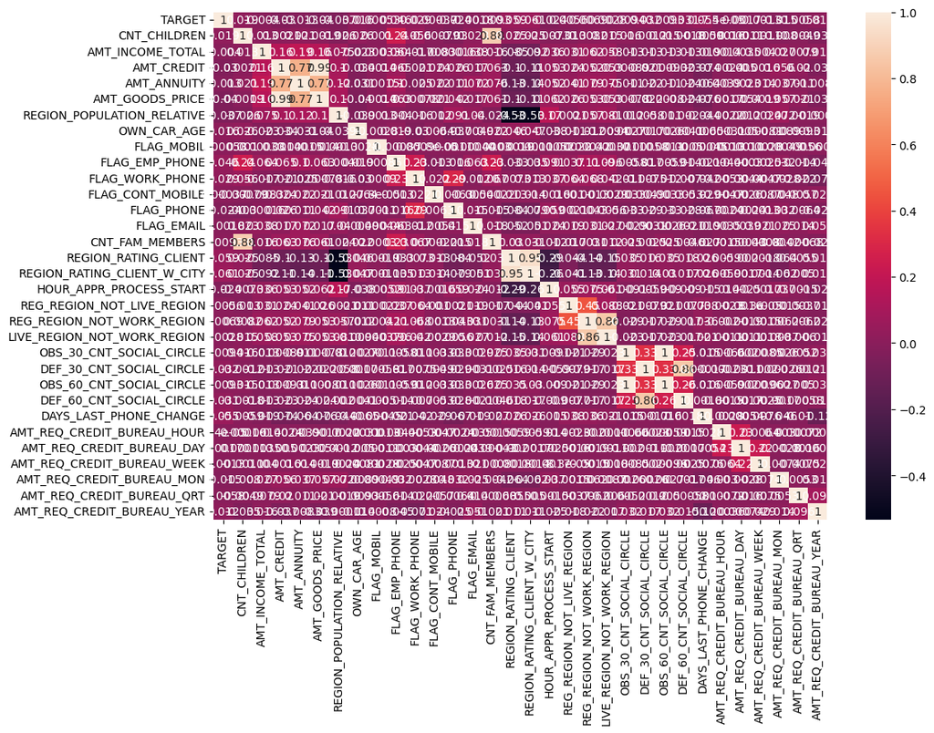

```python
plt.figure(figsize=(12,8))
sns.heatmap(df.corr(),annot=True)
plt.show()
```

### Categorical Feature Distribution

```python
cats = get_cat_cols(df)
```

```python
cats
```

```
['NAME_CONTRACT_TYPE',
 'CODE_GENDER',
 'FLAG_OWN_CAR',
 'FLAG_OWN_REALTY',
 'NAME_TYPE_SUITE',
 'NAME_INCOME_TYPE',
 'NAME_EDUCATION_TYPE',
 'NAME_FAMILY_STATUS',
 'NAME_HOUSING_TYPE',
 'OCCUPATION_TYPE',
 'WEEKDAY_APPR_PROCESS_START',
 'ORGANIZATION_TYPE']
```

```python
# for i in cat_col:
#   fig = px.histogram(df, x=i, width=500, height=400, color=target_variable, barmode="group")
#   fig.show()
```

```python
fig = px.histogram(df, x='NAME_CONTRACT_TYPE',  width=800, height=600, color=target_variable, barmode="group")
fig.show()
```

```python
fig = px.histogram(df, x='CODE_GENDER', width=800, height=600, color=target_variable, barmode="group")
fig.show()
```

```python
fig = px.histogram(df, x='NAME_EDUCATION_TYPE', width=800, height=600, color=target_variable, barmode="group")
fig.show()
```

```python
fig = px.histogram(df, x='NAME_FAMILY_STATUS', width=800, height=600, color=target_variable, barmode="group")
fig.show()
```

Select features and target

```python
X = df.drop([target_variable], axis=1)
y = df[[target_variable]]
```

```python
X.head()
```

|  | NAME_CONTRACT_TYPE | CODE_GENDER | FLAG_OWN_CAR | FLAG_OWN_REALTY | CNT_CHILDREN | AMT_INCOME_TOTAL | AMT_CREDIT | AMT_ANNUITY | AMT_GOODS_PRICE | NAME_TYPE_SUITE | NAME_INCOME_TYPE | NAME_EDUCATION_TYPE | NAME_FAMILY_STATUS | NAME_HOUSING_TYPE | REGION_POPULATION_RELATIVE | OWN_CAR_AGE | FLAG_MOBIL | FLAG_EMP_PHONE | FLAG_WORK_PHONE | FLAG_CONT_MOBILE | FLAG_PHONE | FLAG_EMAIL | OCCUPATION_TYPE | CNT_FAM_MEMBERS | REGION_RATING_CLIENT | REGION_RATING_CLIENT_W_CITY | WEEKDAY_APPR_PROCESS_START | HOUR_APPR_PROCESS_START | REG_REGION_NOT_LIVE_REGION | … |
| --- | --- | --- | --- | --- | --- | --- | --- | --- | --- | --- | --- | --- | --- | --- | --- | --- | --- | --- | --- | --- | --- | --- | --- | --- | --- | --- | --- | --- | --- | --- |
| 0 | Cash loans | M | N | Y | 0 | 202500.0 | 406597.5 | 24700.5 | 351000.0 | Unaccompanied | Working | Secondary / secondary special | Single / not married | House / apartment | 0.018801 | 9.0 | 1 | 1 | 0 | 1 | 1 | 0 | Laborers | 1.0 | 2 | 2 | WEDNESDAY | 10 | 0 | … |
| 1 | Cash loans | F | N | N | 0 | 270000.0 | 1293502.5 | 35698.5 | 1129500.0 | Family | State servant | Higher education | Married | House / apartment | 0.003541 | 9.0 | 1 | 1 | 0 | 1 | 1 | 0 | Core staff | 2.0 | 1 | 1 | MONDAY | 11 | 0 | … |
| 2 | Revolving loans | M | Y | Y | 0 | 67500.0 | 135000.0 | 6750.0 | 135000.0 | Unaccompanied | Working | Secondary / secondary special | Single / not married | House / apartment | 0.010032 | 26.0 | 1 | 1 | 1 | 1 | 1 | 0 | Laborers | 1.0 | 2 | 2 | MONDAY | 9 | 0 | … |
| 3 | Cash loans | F | N | Y | 0 | 135000.0 | 312682.5 | 29686.5 | 297000.0 | Unaccompanied | Working | Secondary / secondary special | Civil marriage | House / apartment | 0.008019 | 9.0 | 1 | 1 | 0 | 1 | 0 | 0 | Laborers | 2.0 | 2 | 2 | WEDNESDAY | 17 | 0 | … |
| 4 | Cash loans | M | N | Y | 0 | 121500.0 | 513000.0 | 21865.5 | 513000.0 | Unaccompanied | Working | Secondary / secondary special | Single / not married | House / apartment | 0.028663 | 9.0 | 1 | 1 | 0 | 1 | 0 | 0 | Core staff | 1.0 | 2 | 2 | THURSDAY | 11 | 0 | … |

```python
y.head()
```

|  | TARGET |
| --- | --- |
| 0 | 1 |
| 1 | 0 |
| 2 | 0 |
| 3 | 0 |
| 4 | 0 |

```python
# For Modelling
from sklearn.model_selection import train_test_split
from sklearn.linear_model import LogisticRegression
from sklearn.metrics import accuracy_score
from sklearn.metrics import classification_report
from sklearn.tree import DecisionTreeClassifier
from sklearn import *
from imblearn import *
from sklearn.preprocessing import OneHotEncoder, StandardScaler, MinMaxScaler, LabelEncoder
from sklearn.compose import ColumnTransformer
from sklearn.ensemble import RandomForestClassifier
from imblearn.under_sampling import RandomUnderSampler
from xgboost import XGBClassifier
from sklearn.metrics import classification_report, confusion_matrix, ConfusionMatrixDisplay
from sklearn.metrics import recall_score, precision_score, roc_auc_score
from imblearn.pipeline import Pipeline
from sklearn.model_selection import train_test_split
```

#### Data Prepocessing

##### Normalization - Numerical Feature

```python
num_col = get_num_cols(X)
num_col
```

```
['CNT_CHILDREN',
 'FLAG_MOBIL',
 'FLAG_EMP_PHONE',
 'FLAG_WORK_PHONE',
 'FLAG_CONT_MOBILE',
 'FLAG_PHONE',
 'FLAG_EMAIL',
 'REGION_RATING_CLIENT',
 'REGION_RATING_CLIENT_W_CITY',
 'HOUR_APPR_PROCESS_START',
 'REG_REGION_NOT_LIVE_REGION',
 'REG_REGION_NOT_WORK_REGION',
 'LIVE_REGION_NOT_WORK_REGION',
 'AMT_INCOME_TOTAL',
 'AMT_CREDIT',
 'AMT_ANNUITY',
 'AMT_GOODS_PRICE',
 'REGION_POPULATION_RELATIVE',
 'OWN_CAR_AGE',
 'CNT_FAM_MEMBERS',
 'OBS_30_CNT_SOCIAL_CIRCLE',
 'DEF_30_CNT_SOCIAL_CIRCLE',
 'OBS_60_CNT_SOCIAL_CIRCLE',
 'DEF_60_CNT_SOCIAL_CIRCLE',
 'DAYS_LAST_PHONE_CHANGE',
 'AMT_REQ_CREDIT_BUREAU_HOUR',
 'AMT_REQ_CREDIT_BUREAU_DAY',
 'AMT_REQ_CREDIT_BUREAU_WEEK',
 'AMT_REQ_CREDIT_BUREAU_MON',
 'AMT_REQ_CREDIT_BUREAU_QRT',
 'AMT_REQ_CREDIT_BUREAU_YEAR']
```

```python
scaler = MinMaxScaler()
X_transform = scaler.fit_transform(X[num_col])
```

```python
X_transform = pd.DataFrame(X_transform,columns = num_col)
print(X_transform.shape)
X_transform.head()
```

```
(307500, 31)
```

|  | CNT_CHILDREN | FLAG_MOBIL | FLAG_EMP_PHONE | FLAG_WORK_PHONE | FLAG_CONT_MOBILE | FLAG_PHONE | FLAG_EMAIL | REGION_RATING_CLIENT | REGION_RATING_CLIENT_W_CITY | HOUR_APPR_PROCESS_START | REG_REGION_NOT_LIVE_REGION | REG_REGION_NOT_WORK_REGION | LIVE_REGION_NOT_WORK_REGION | AMT_INCOME_TOTAL | AMT_CREDIT | AMT_ANNUITY | AMT_GOODS_PRICE | REGION_POPULATION_RELATIVE | OWN_CAR_AGE | CNT_FAM_MEMBERS | OBS_30_CNT_SOCIAL_CIRCLE | DEF_30_CNT_SOCIAL_CIRCLE | OBS_60_CNT_SOCIAL_CIRCLE | DEF_60_CNT_SOCIAL_CIRCLE | DAYS_LAST_PHONE_CHANGE | AMT_REQ_CREDIT_BUREAU_HOUR | AMT_REQ_CREDIT_BUREAU_DAY | AMT_REQ_CREDIT_BUREAU_WEEK | AMT_REQ_CREDIT_BUREAU_MON | … |
| --- | --- | --- | --- | --- | --- | --- | --- | --- | --- | --- | --- | --- | --- | --- | --- | --- | --- | --- | --- | --- | --- | --- | --- | --- | --- | --- | --- | --- | --- | --- |
| 0 | 0.0 | 1.0 | 1.0 | 0.0 | 1.0 | 1.0 | 0.0 | 0.5 | 0.5 | 0.434783 | 0.0 | 0.0 | 0.0 | 0.001512 | 0.090287 | 0.090032 | 0.077441 | 0.256321 | 0.098901 | 0.000000 | 0.005747 | 0.058824 | 0.005814 | 0.083333 | 0.735788 | 0.0 | 0.0 | 0.0 | 0.0 | … |
| 1 | 0.0 | 1.0 | 1.0 | 0.0 | 1.0 | 1.0 | 0.0 | 0.0 | 0.0 | 0.478261 | 0.0 | 0.0 | 0.0 | 0.002089 | 0.311736 | 0.132924 | 0.271605 | 0.045016 | 0.098901 | 0.052632 | 0.002874 | 0.000000 | 0.002907 | 0.000000 | 0.807083 | 0.0 | 0.0 | 0.0 | 0.0 | … |
| 2 | 0.0 | 1.0 | 1.0 | 1.0 | 1.0 | 1.0 | 0.0 | 0.5 | 0.5 | 0.391304 | 0.0 | 0.0 | 0.0 | 0.000358 | 0.022472 | 0.020025 | 0.023569 | 0.134897 | 0.285714 | 0.000000 | 0.000000 | 0.000000 | 0.000000 | 0.000000 | 0.810112 | 0.0 | 0.0 | 0.0 | 0.0 | … |
| 3 | 0.0 | 1.0 | 1.0 | 0.0 | 1.0 | 0.0 | 0.0 | 0.5 | 0.5 | 0.739130 | 0.0 | 0.0 | 0.0 | 0.000935 | 0.066837 | 0.109477 | 0.063973 | 0.107023 | 0.098901 | 0.052632 | 0.005747 | 0.000000 | 0.005814 | 0.000000 | 0.856244 | 0.0 | 0.0 | 0.0 | 0.0 | … |
| 4 | 0.0 | 1.0 | 1.0 | 0.0 | 1.0 | 0.0 | 0.0 | 0.5 | 0.5 | 0.478261 | 0.0 | 0.0 | 0.0 | 0.000819 | 0.116854 | 0.078975 | 0.117845 | 0.392880 | 0.098901 | 0.000000 | 0.000000 | 0.000000 | 0.000000 | 0.000000 | 0.742311 | 0.0 | 0.0 | 0.0 | 0.0 | … |

```python
cat_col = get_cat_cols(df)
cat_col
```

```
['NAME_CONTRACT_TYPE',
 'CODE_GENDER',
 'FLAG_OWN_CAR',
 'FLAG_OWN_REALTY',
 'NAME_TYPE_SUITE',
 'NAME_INCOME_TYPE',
 'NAME_EDUCATION_TYPE',
 'NAME_FAMILY_STATUS',
 'NAME_HOUSING_TYPE',
 'OCCUPATION_TYPE',
 'WEEKDAY_APPR_PROCESS_START',
 'ORGANIZATION_TYPE']
```

```python
print(X_transform.shape)
X_transform.head()
```

```
(307500, 31)
```

|  | CNT_CHILDREN | FLAG_MOBIL | FLAG_EMP_PHONE | FLAG_WORK_PHONE | FLAG_CONT_MOBILE | FLAG_PHONE | FLAG_EMAIL | REGION_RATING_CLIENT | REGION_RATING_CLIENT_W_CITY | HOUR_APPR_PROCESS_START | REG_REGION_NOT_LIVE_REGION | REG_REGION_NOT_WORK_REGION | LIVE_REGION_NOT_WORK_REGION | AMT_INCOME_TOTAL | AMT_CREDIT | AMT_ANNUITY | AMT_GOODS_PRICE | REGION_POPULATION_RELATIVE | OWN_CAR_AGE | CNT_FAM_MEMBERS | OBS_30_CNT_SOCIAL_CIRCLE | DEF_30_CNT_SOCIAL_CIRCLE | OBS_60_CNT_SOCIAL_CIRCLE | DEF_60_CNT_SOCIAL_CIRCLE | DAYS_LAST_PHONE_CHANGE | AMT_REQ_CREDIT_BUREAU_HOUR | AMT_REQ_CREDIT_BUREAU_DAY | AMT_REQ_CREDIT_BUREAU_WEEK | AMT_REQ_CREDIT_BUREAU_MON | … |
| --- | --- | --- | --- | --- | --- | --- | --- | --- | --- | --- | --- | --- | --- | --- | --- | --- | --- | --- | --- | --- | --- | --- | --- | --- | --- | --- | --- | --- | --- | --- |
| 0 | 0.0 | 1.0 | 1.0 | 0.0 | 1.0 | 1.0 | 0.0 | 0.5 | 0.5 | 0.434783 | 0.0 | 0.0 | 0.0 | 0.001512 | 0.090287 | 0.090032 | 0.077441 | 0.256321 | 0.098901 | 0.000000 | 0.005747 | 0.058824 | 0.005814 | 0.083333 | 0.735788 | 0.0 | 0.0 | 0.0 | 0.0 | … |
| 1 | 0.0 | 1.0 | 1.0 | 0.0 | 1.0 | 1.0 | 0.0 | 0.0 | 0.0 | 0.478261 | 0.0 | 0.0 | 0.0 | 0.002089 | 0.311736 | 0.132924 | 0.271605 | 0.045016 | 0.098901 | 0.052632 | 0.002874 | 0.000000 | 0.002907 | 0.000000 | 0.807083 | 0.0 | 0.0 | 0.0 | 0.0 | … |
| 2 | 0.0 | 1.0 | 1.0 | 1.0 | 1.0 | 1.0 | 0.0 | 0.5 | 0.5 | 0.391304 | 0.0 | 0.0 | 0.0 | 0.000358 | 0.022472 | 0.020025 | 0.023569 | 0.134897 | 0.285714 | 0.000000 | 0.000000 | 0.000000 | 0.000000 | 0.000000 | 0.810112 | 0.0 | 0.0 | 0.0 | 0.0 | … |
| 3 | 0.0 | 1.0 | 1.0 | 0.0 | 1.0 | 0.0 | 0.0 | 0.5 | 0.5 | 0.739130 | 0.0 | 0.0 | 0.0 | 0.000935 | 0.066837 | 0.109477 | 0.063973 | 0.107023 | 0.098901 | 0.052632 | 0.005747 | 0.000000 | 0.005814 | 0.000000 | 0.856244 | 0.0 | 0.0 | 0.0 | 0.0 | … |
| 4 | 0.0 | 1.0 | 1.0 | 0.0 | 1.0 | 0.0 | 0.0 | 0.5 | 0.5 | 0.478261 | 0.0 | 0.0 | 0.0 | 0.000819 | 0.116854 | 0.078975 | 0.117845 | 0.392880 | 0.098901 | 0.000000 | 0.000000 | 0.000000 | 0.000000 | 0.000000 | 0.742311 | 0.0 | 0.0 | 0.0 | 0.0 | … |

```python
print(y.shape)
y.head()
```

```
(307500, 1)
```

|  | TARGET |
| --- | --- |
| 0 | 1 |
| 1 | 0 |
| 2 | 0 |
| 3 | 0 |
| 4 | 0 |

```python
new_all = pd.concat([y, X[cat_col], X_transform], axis=1) #Data Train
print(new_all.shape)
```

```
(307511, 44)
```

```python
new_all.head()
```

|  | TARGET | NAME_CONTRACT_TYPE | CODE_GENDER | FLAG_OWN_CAR | FLAG_OWN_REALTY | NAME_TYPE_SUITE | NAME_INCOME_TYPE | NAME_EDUCATION_TYPE | NAME_FAMILY_STATUS | NAME_HOUSING_TYPE | OCCUPATION_TYPE | WEEKDAY_APPR_PROCESS_START | ORGANIZATION_TYPE | CNT_CHILDREN | FLAG_MOBIL | FLAG_EMP_PHONE | FLAG_WORK_PHONE | FLAG_CONT_MOBILE | FLAG_PHONE | FLAG_EMAIL | REGION_RATING_CLIENT | REGION_RATING_CLIENT_W_CITY | HOUR_APPR_PROCESS_START | REG_REGION_NOT_LIVE_REGION | REG_REGION_NOT_WORK_REGION | LIVE_REGION_NOT_WORK_REGION | AMT_INCOME_TOTAL | AMT_CREDIT | AMT_ANNUITY | … |
| --- | --- | --- | --- | --- | --- | --- | --- | --- | --- | --- | --- | --- | --- | --- | --- | --- | --- | --- | --- | --- | --- | --- | --- | --- | --- | --- | --- | --- | --- | --- |
| 0 | 1.0 | Cash loans | M | N | Y | Unaccompanied | Working | Secondary / secondary special | Single / not married | House / apartment | Laborers | WEDNESDAY | Business Entity Type 3 | 0.0 | 1.0 | 1.0 | 0.0 | 1.0 | 1.0 | 0.0 | 0.5 | 0.5 | 0.434783 | 0.0 | 0.0 | 0.0 | 0.001512 | 0.090287 | 0.090032 | … |
| 1 | 0.0 | Cash loans | F | N | N | Family | State servant | Higher education | Married | House / apartment | Core staff | MONDAY | School | 0.0 | 1.0 | 1.0 | 0.0 | 1.0 | 1.0 | 0.0 | 0.0 | 0.0 | 0.478261 | 0.0 | 0.0 | 0.0 | 0.002089 | 0.311736 | 0.132924 | … |
| 2 | 0.0 | Revolving loans | M | Y | Y | Unaccompanied | Working | Secondary / secondary special | Single / not married | House / apartment | Laborers | MONDAY | Government | 0.0 | 1.0 | 1.0 | 1.0 | 1.0 | 1.0 | 0.0 | 0.5 | 0.5 | 0.391304 | 0.0 | 0.0 | 0.0 | 0.000358 | 0.022472 | 0.020025 | … |
| 3 | 0.0 | Cash loans | F | N | Y | Unaccompanied | Working | Secondary / secondary special | Civil marriage | House / apartment | Laborers | WEDNESDAY | Business Entity Type 3 | 0.0 | 1.0 | 1.0 | 0.0 | 1.0 | 0.0 | 0.0 | 0.5 | 0.5 | 0.739130 | 0.0 | 0.0 | 0.0 | 0.000935 | 0.066837 | 0.109477 | … |
| 4 | 0.0 | Cash loans | M | N | Y | Unaccompanied | Working | Secondary / secondary special | Single / not married | House / apartment | Core staff | THURSDAY | Religion | 0.0 | 1.0 | 1.0 | 0.0 | 1.0 | 0.0 | 0.0 | 0.5 | 0.5 | 0.478261 | 0.0 | 0.0 | 0.0 | 0.000819 | 0.116854 | 0.078975 | … |

```python
cat_col
```

```
['NAME_CONTRACT_TYPE',
 'CODE_GENDER',
 'FLAG_OWN_CAR',
 'FLAG_OWN_REALTY',
 'NAME_TYPE_SUITE',
 'NAME_INCOME_TYPE',
 'NAME_EDUCATION_TYPE',
 'NAME_FAMILY_STATUS',
 'NAME_HOUSING_TYPE',
 'OCCUPATION_TYPE',
 'WEEKDAY_APPR_PROCESS_START',
 'ORGANIZATION_TYPE']
```

```python
labelencoder=LabelEncoder()

# for i in cat_col:
#     new_all[i] = labelencoder.fit_transform(new_all[i])

new_all['NAME_CONTRACT_TYPE'] = labelencoder.fit_transform(new_all['NAME_CONTRACT_TYPE'])
new_all['CODE_GENDER'] = labelencoder.fit_transform(new_all['CODE_GENDER'])
new_all['FLAG_OWN_CAR'] = labelencoder.fit_transform(new_all['FLAG_OWN_CAR'])
new_all['FLAG_OWN_REALTY'] = labelencoder.fit_transform(new_all['FLAG_OWN_REALTY'])
new_all['NAME_TYPE_SUITE'] = labelencoder.fit_transform(new_all['NAME_TYPE_SUITE'])
new_all['NAME_INCOME_TYPE'] = labelencoder.fit_transform(new_all['NAME_INCOME_TYPE'])
new_all['NAME_EDUCATION_TYPE'] = labelencoder.fit_transform(new_all['NAME_EDUCATION_TYPE'])
new_all['NAME_FAMILY_STATUS'] = labelencoder.fit_transform(new_all['NAME_FAMILY_STATUS'])
new_all['NAME_HOUSING_TYPE'] = labelencoder.fit_transform(new_all['NAME_HOUSING_TYPE'])
new_all['OCCUPATION_TYPE'] = labelencoder.fit_transform(new_all['OCCUPATION_TYPE'])
new_all['WEEKDAY_APPR_PROCESS_START'] = labelencoder.fit_transform(new_all['WEEKDAY_APPR_PROCESS_START'])
new_all['ORGANIZATION_TYPE'] = labelencoder.fit_transform(new_all['ORGANIZATION_TYPE'])


new_all.head()
```

|  | TARGET | NAME_CONTRACT_TYPE | CODE_GENDER | FLAG_OWN_CAR | FLAG_OWN_REALTY | NAME_TYPE_SUITE | NAME_INCOME_TYPE | NAME_EDUCATION_TYPE | NAME_FAMILY_STATUS | NAME_HOUSING_TYPE | OCCUPATION_TYPE | WEEKDAY_APPR_PROCESS_START | ORGANIZATION_TYPE | CNT_CHILDREN | FLAG_MOBIL | FLAG_EMP_PHONE | FLAG_WORK_PHONE | FLAG_CONT_MOBILE | FLAG_PHONE | FLAG_EMAIL | REGION_RATING_CLIENT | REGION_RATING_CLIENT_W_CITY | HOUR_APPR_PROCESS_START | REG_REGION_NOT_LIVE_REGION | REG_REGION_NOT_WORK_REGION | LIVE_REGION_NOT_WORK_REGION | AMT_INCOME_TOTAL | AMT_CREDIT | AMT_ANNUITY | … |
| --- | --- | --- | --- | --- | --- | --- | --- | --- | --- | --- | --- | --- | --- | --- | --- | --- | --- | --- | --- | --- | --- | --- | --- | --- | --- | --- | --- | --- | --- | --- |
| 0 | 1.0 | 0 | 1 | 0 | 1 | 6 | 7 | 4 | 3 | 1 | 8 | 6 | 5 | 0.0 | 1.0 | 1.0 | 0.0 | 1.0 | 1.0 | 0.0 | 0.5 | 0.5 | 0.434783 | 0.0 | 0.0 | 0.0 | 0.001512 | 0.090287 | 0.090032 | … |
| 1 | 0.0 | 0 | 0 | 0 | 0 | 1 | 4 | 1 | 1 | 1 | 3 | 1 | 39 | 0.0 | 1.0 | 1.0 | 0.0 | 1.0 | 1.0 | 0.0 | 0.0 | 0.0 | 0.478261 | 0.0 | 0.0 | 0.0 | 0.002089 | 0.311736 | 0.132924 | … |
| 2 | 0.0 | 1 | 1 | 1 | 1 | 6 | 7 | 4 | 3 | 1 | 8 | 1 | 11 | 0.0 | 1.0 | 1.0 | 1.0 | 1.0 | 1.0 | 0.0 | 0.5 | 0.5 | 0.391304 | 0.0 | 0.0 | 0.0 | 0.000358 | 0.022472 | 0.020025 | … |
| 3 | 0.0 | 0 | 0 | 0 | 1 | 6 | 7 | 4 | 0 | 1 | 8 | 6 | 5 | 0.0 | 1.0 | 1.0 | 0.0 | 1.0 | 0.0 | 0.0 | 0.5 | 0.5 | 0.739130 | 0.0 | 0.0 | 0.0 | 0.000935 | 0.066837 | 0.109477 | … |
| 4 | 0.0 | 0 | 1 | 0 | 1 | 6 | 7 | 4 | 3 | 1 | 3 | 4 | 37 | 0.0 | 1.0 | 1.0 | 0.0 | 1.0 | 0.0 | 0.0 | 0.5 | 0.5 | 0.478261 | 0.0 | 0.0 | 0.0 | 0.000819 | 0.116854 | 0.078975 | … |

```python
check_missing(new_all)
```

|  | percentage | frequency | var_type |
| --- | --- | --- | --- |
| TARGET | 0.003577 | 11 | float64 |
| OBS_30_CNT_SOCIAL_CIRCLE | 0.003577 | 11 | float64 |
| LIVE_REGION_NOT_WORK_REGION | 0.003577 | 11 | float64 |
| AMT_INCOME_TOTAL | 0.003577 | 11 | float64 |
| AMT_CREDIT | 0.003577 | 11 | float64 |
| AMT_ANNUITY | 0.003577 | 11 | float64 |
| AMT_GOODS_PRICE | 0.003577 | 11 | float64 |
| REGION_POPULATION_RELATIVE | 0.003577 | 11 | float64 |
| OWN_CAR_AGE | 0.003577 | 11 | float64 |
| CNT_FAM_MEMBERS | 0.003577 | 11 | float64 |
| DEF_30_CNT_SOCIAL_CIRCLE | 0.003577 | 11 | float64 |
| REG_REGION_NOT_LIVE_REGION | 0.003577 | 11 | float64 |
| OBS_60_CNT_SOCIAL_CIRCLE | 0.003577 | 11 | float64 |
| DEF_60_CNT_SOCIAL_CIRCLE | 0.003577 | 11 | float64 |
| DAYS_LAST_PHONE_CHANGE | 0.003577 | 11 | float64 |
| AMT_REQ_CREDIT_BUREAU_HOUR | 0.003577 | 11 | float64 |
| AMT_REQ_CREDIT_BUREAU_DAY | 0.003577 | 11 | float64 |
| AMT_REQ_CREDIT_BUREAU_WEEK | 0.003577 | 11 | float64 |
| AMT_REQ_CREDIT_BUREAU_MON | 0.003577 | 11 | float64 |
| AMT_REQ_CREDIT_BUREAU_QRT | 0.003577 | 11 | float64 |
| REG_REGION_NOT_WORK_REGION | 0.003577 | 11 | float64 |
| HOUR_APPR_PROCESS_START | 0.003577 | 11 | float64 |
| AMT_REQ_CREDIT_BUREAU_YEAR | 0.003577 | 11 | float64 |
| REGION_RATING_CLIENT | 0.003577 | 11 | float64 |
| FLAG_EMAIL | 0.003577 | 11 | float64 |
| FLAG_PHONE | 0.003577 | 11 | float64 |
| FLAG_CONT_MOBILE | 0.003577 | 11 | float64 |
| FLAG_WORK_PHONE | 0.003577 | 11 | float64 |
| FLAG_EMP_PHONE | 0.003577 | 11 | float64 |
| FLAG_MOBIL | 0.003577 | 11 | float64 |
| CNT_CHILDREN | 0.003577 | 11 | float64 |
| REGION_RATING_CLIENT_W_CITY | 0.003577 | 11 | float64 |

```python
for i in new_all.columns:
    data = df[i]
    types = str(data.dtype)
    if types == 'object':
        new_all[i].fillna(new_all[i].mode()[0], inplace=True)
    else:
        new_all[i].fillna(new_all[i].median(), inplace=True)
```

#### Train-test Split

```python
X = new_all.drop(target_variable, axis=1)
y = new_all[[target_variable]]
```

```python
get_head(X)
```

```
Shape : (307511, 43)
```

|  | NAME_CONTRACT_TYPE | CODE_GENDER | FLAG_OWN_CAR | FLAG_OWN_REALTY | NAME_TYPE_SUITE | NAME_INCOME_TYPE | NAME_EDUCATION_TYPE | NAME_FAMILY_STATUS | NAME_HOUSING_TYPE | OCCUPATION_TYPE | WEEKDAY_APPR_PROCESS_START | ORGANIZATION_TYPE | CNT_CHILDREN | FLAG_MOBIL | FLAG_EMP_PHONE | FLAG_WORK_PHONE | FLAG_CONT_MOBILE | FLAG_PHONE | FLAG_EMAIL | REGION_RATING_CLIENT | REGION_RATING_CLIENT_W_CITY | HOUR_APPR_PROCESS_START | REG_REGION_NOT_LIVE_REGION | REG_REGION_NOT_WORK_REGION | LIVE_REGION_NOT_WORK_REGION | AMT_INCOME_TOTAL | AMT_CREDIT | AMT_ANNUITY | AMT_GOODS_PRICE | … |
| --- | --- | --- | --- | --- | --- | --- | --- | --- | --- | --- | --- | --- | --- | --- | --- | --- | --- | --- | --- | --- | --- | --- | --- | --- | --- | --- | --- | --- | --- | --- |
| 0 | 0 | 1 | 0 | 1 | 6 | 7 | 4 | 3 | 1 | 8 | 6 | 5 | 0.0 | 1.0 | 1.0 | 0.0 | 1.0 | 1.0 | 0.0 | 0.5 | 0.5 | 0.434783 | 0.0 | 0.0 | 0.0 | 0.001512 | 0.090287 | 0.090032 | 0.077441 | … |
| 1 | 0 | 0 | 0 | 0 | 1 | 4 | 1 | 1 | 1 | 3 | 1 | 39 | 0.0 | 1.0 | 1.0 | 0.0 | 1.0 | 1.0 | 0.0 | 0.0 | 0.0 | 0.478261 | 0.0 | 0.0 | 0.0 | 0.002089 | 0.311736 | 0.132924 | 0.271605 | … |
| 2 | 1 | 1 | 1 | 1 | 6 | 7 | 4 | 3 | 1 | 8 | 1 | 11 | 0.0 | 1.0 | 1.0 | 1.0 | 1.0 | 1.0 | 0.0 | 0.5 | 0.5 | 0.391304 | 0.0 | 0.0 | 0.0 | 0.000358 | 0.022472 | 0.020025 | 0.023569 | … |
| 3 | 0 | 0 | 0 | 1 | 6 | 7 | 4 | 0 | 1 | 8 | 6 | 5 | 0.0 | 1.0 | 1.0 | 0.0 | 1.0 | 0.0 | 0.0 | 0.5 | 0.5 | 0.739130 | 0.0 | 0.0 | 0.0 | 0.000935 | 0.066837 | 0.109477 | 0.063973 | … |
| 4 | 0 | 1 | 0 | 1 | 6 | 7 | 4 | 3 | 1 | 3 | 4 | 37 | 0.0 | 1.0 | 1.0 | 0.0 | 1.0 | 0.0 | 0.0 | 0.5 | 0.5 | 0.478261 | 0.0 | 0.0 | 0.0 | 0.000819 | 0.116854 | 0.078975 | 0.117845 | … |

```python
get_head(y)
```

```
Shape : (307511, 1)
```

|  | TARGET |
| --- | --- |
| 0 | 1.0 |
| 1 | 0.0 |
| 2 | 0.0 |
| 3 | 0.0 |
| 4 | 0.0 |

```python
X_train,X_test,y_train,y_test = train_test_split(X, y, test_size = 0.3, random_state = 11, stratify=y)
print('Shape of X_train dan y_train: ', X_train.shape, y_train.shape)
print('Shape of X_test dan y_test: ', X_test.shape, y_test.shape)
```

```
Shape of X_train dan y_train:  (215257, 43) (215257, 1)
Shape of X_test dan y_test:  (92254, 43) (92254, 1)
```

```python
y.value_counts(normalize=True)
```

```
TARGET
0.0       0.919274
1.0       0.080726
dtype: float64
```

```python
y_train.value_counts(normalize=True)
```

```
TARGET
0.0       0.919273
1.0       0.080727
dtype: float64
```

```python
y_test.value_counts(normalize=True)
```

```
TARGET
0.0       0.919277
1.0       0.080723
dtype: float64
```

#### Resampling

```python
y_train.value_counts()
```

```
TARGET
0.0       197880
1.0        17377
dtype: int64
```

```python
y_train.value_counts(normalize=True)
```

```
TARGET
0.0       0.919273
1.0       0.080727
dtype: float64
```

# Random Under Sampling

```python
X_rus, y_rus = RandomUnderSampler().fit_resample(X_train, y_train)
```

```python
y_rus.value_counts()
```

```
TARGET
0.0       17377
1.0       17377
dtype: int64
```

```python
y_rus.value_counts(normalize=True)
```

```
TARGET
0.0       0.5
1.0       0.5
dtype: float64
```

#### Modeling

```python
# membuat fungsi evaluasi model
def evaluasi_model(model, X_test, y_test):
    y_pred = model.predict(X_test)
    return roc_auc_score(y_test, y_pred)
```

##### Decision Tree

```python
dtc = DecisionTreeClassifier()
dtc.fit(X_train, y_train)
```

```
DecisionTreeClassifier()
```

roc_auc_score tanpa RUS

```python
evaluasi_model(dtc, X_test, y_test)
```

```
0.5072372323069139
```

roc_auc_score dengan RUS

```python
evaluasi_model(dtc,  X_rus, y_rus)
```

```
1.0
```

##### XGBoost

```python
xgb = XGBClassifier()
xgb.fit(X_train, y_train)
```

```
XGBClassifier(base_score=None, booster=None, callbacks=None,
              colsample_bylevel=None, colsample_bynode=None,
              colsample_bytree=None, early_stopping_rounds=None,
              enable_categorical=False, eval_metric=None, feature_types=None,
              gamma=None, gpu_id=None, grow_policy=None, importance_type=None,
              interaction_constraints=None, learning_rate=None, max_bin=None,
              max_cat_threshold=None, max_cat_to_onehot=None,
              max_delta_step=None, max_depth=None, max_leaves=None,
              min_child_weight=None, missing=nan, monotone_constraints=None,
              n_estimators=100, n_jobs=None, num_parallel_tree=None,
              predictor=None, random_state=None, ...)
```

roc_auc_score tanpa RUS

```python
evaluasi_model(xgb, X_test, y_test)
```

```
0.5000140794730105
```

roc_auc_score dengan RUS

```python
evaluasi_model(xgb,  X_rus, y_rus)
```

```
0.5030212349657593
```

##### Random Forest

```python
rf = RandomForestClassifier()
rf.fit(X_train, y_train)
```

```
RandomForestClassifier()
```

roc_auc_score tanpa RUS

```python
evaluasi_model(rf, X_test, y_test)
```

```
0.5
```

roc_auc_score dengan RUS

```python
evaluasi_model(rf,  X_rus, y_rus)
```

```
0.9996834896702538
```

### Decision Tree Classifier

```python
dtree = DecisionTreeClassifier()
dtree.fit(X_train, y_train)

# Accuracy Train
print('Decision Tree Classifier')
print(' ')
print('Accuracy Train')
dtree_Train_pred = dtree.predict(X_train)
print(classification_report(y_train, dtree_Train_pred))

print('===================================================')
# Accuracy Test
print('Accuracy Test')
dtree_Test_pred = dtree.predict(X_test)
print(classification_report(y_test, dtree_Test_pred))
```

```
Decision Tree Classifier

Accuracy Train
              precision    recall  f1-score   support

         0.0       1.00      1.00      1.00    197880
         1.0       1.00      1.00      1.00     17377

    accuracy                           1.00    215257
   macro avg       1.00      1.00      1.00    215257
weighted avg       1.00      1.00      1.00    215257

===================================================
Accuracy Test
              precision    recall  f1-score   support

         0.0       0.92      0.90      0.91     84807
         1.0       0.09      0.11      0.10      7447

    accuracy                           0.84     92254
   macro avg       0.51      0.51      0.51     92254
weighted avg       0.85      0.84      0.85     92254
```

```python
dtree = DecisionTreeClassifier()
dtree.fit(X_train, y_train)

# Accuracy Train
print('Decision Tree Classifier')
print(' ')
print('Accuracy Train')
dtree_Train_pred = dtree.predict(X_rus)
print(classification_report(y_rus, dtree_Train_pred))

print('===================================================')
# Accuracy Test
print('Accuracy Test')
dtree_Test_pred = dtree.predict(X_rus)
print(classification_report(y_rus, dtree_Test_pred))
```

```
Decision Tree Classifier

Accuracy Train
              precision    recall  f1-score   support

         0.0       1.00      1.00      1.00     17377
         1.0       1.00      1.00      1.00     17377

    accuracy                           1.00     34754
   macro avg       1.00      1.00      1.00     34754
weighted avg       1.00      1.00      1.00     34754

===================================================
Accuracy Test
              precision    recall  f1-score   support

         0.0       1.00      1.00      1.00     17377
         1.0       1.00      1.00      1.00     17377

    accuracy                           1.00     34754
   macro avg       1.00      1.00      1.00     34754
weighted avg       1.00      1.00      1.00     34754
```

### XGBClassifier

```python
xgb = XGBClassifier()
xgb.fit(X_train, y_train)

# Accuracy Train
print('XGBClassifier')
print(' ')
print('Accuracy Train')
xgb_Train_pred = xgb.predict(X_train)
print(classification_report(y_train,xgb_Train_pred))

print('===================================================')
# Accuracy Test
print('Accuracy Test')
xgb_Test_pred = xgb.predict(X_test)
print(classification_report(y_test,xgb_Test_pred))
```

```
XGBClassifier

Accuracy Train
              precision    recall  f1-score   support

         0.0       0.92      1.00      0.96    197880
         1.0       1.00      0.01      0.01     17377

    accuracy                           0.92    215257
   macro avg       0.96      0.50      0.49    215257
weighted avg       0.93      0.92      0.88    215257

===================================================
Accuracy Test
              precision    recall  f1-score   support

         0.0       0.92      1.00      0.96     84807
         1.0       0.10      0.00      0.00      7447

    accuracy                           0.92     92254
   macro avg       0.51      0.50      0.48     92254
weighted avg       0.85      0.92      0.88     92254
```

```python
xgb = XGBClassifier()
xgb.fit(X_train, y_train)

# Accuracy Train
print('XGBClassifier')
print(' ')
print('Accuracy Train')
xgb_Train_pred = xgb.predict(X_rus)
print(classification_report(y_rus, xgb_Train_pred))

print('===================================================')
# Accuracy Test
print('Accuracy Test')
xgb_Test_pred = xgb.predict(X_rus)
print(classification_report(y_rus, xgb_Test_pred))
```

```
XGBClassifier

Accuracy Train
              precision    recall  f1-score   support

         0.0       0.50      1.00      0.67     17377
         1.0       1.00      0.01      0.01     17377

    accuracy                           0.50     34754
   macro avg       0.75      0.50      0.34     34754
weighted avg       0.75      0.50      0.34     34754

===================================================
Accuracy Test
              precision    recall  f1-score   support

         0.0       0.50      1.00      0.67     17377
         1.0       1.00      0.01      0.01     17377

    accuracy                           0.50     34754
   macro avg       0.75      0.50      0.34     34754
weighted avg       0.75      0.50      0.34     34754
```

### Random Forest

```python
rf = RandomForestClassifier()
rf.fit(X_train, y_train)

# Accuracy Train
print('Random Forest Classifier')
print(' ')
print('Accuracy Train')
rf_Train_pred = rf.predict(X_train)
print(classification_report(y_train,rf_Train_pred))

print('===================================================')
# Accuracy Test
print('Accuracy Test')
rf_Test_pred = rf.predict(X_test)
print(classification_report(y_test, rf_Test_pred))
```

```
Random Forest Classifier

Accuracy Train
              precision    recall  f1-score   support

         0.0       1.00      1.00      1.00    197880
         1.0       1.00      1.00      1.00     17377

    accuracy                           1.00    215257
   macro avg       1.00      1.00      1.00    215257
weighted avg       1.00      1.00      1.00    215257

===================================================
Accuracy Test
              precision    recall  f1-score   support

         0.0       0.92      1.00      0.96     84807
         1.0       0.00      0.00      0.00      7447

    accuracy                           0.92     92254
   macro avg       0.46      0.50      0.48     92254
weighted avg       0.85      0.92      0.88     92254
```

```python
rf = RandomForestClassifier()
rf.fit(X_train, y_train)

# Accuracy Train
print('RandomForestClassifier')
print(' ')
print('Accuracy Train')
rf_Train_pred=rf.predict(X_rus)
print(classification_report(y_rus, rf_Train_pred))

print('===================================================')
# Accuracy Test
print('Accuracy Test')
rf_Test_pred=rf.predict(X_rus)
print(classification_report(y_rus, rf_Test_pred))
```

```
RandomForestClassifier

Accuracy Train
              precision    recall  f1-score   support

         0.0       1.00      1.00      1.00     17377
         1.0       1.00      1.00      1.00     17377

    accuracy                           1.00     34754
   macro avg       1.00      1.00      1.00     34754
weighted avg       1.00      1.00      1.00     34754

===================================================
Accuracy Test
              precision    recall  f1-score   support

         0.0       1.00      1.00      1.00     17377
         1.0       1.00      1.00      1.00     17377

    accuracy                           1.00     34754
   macro avg       1.00      1.00      1.00     34754
weighted avg       1.00      1.00      1.00     34754
```

### Logistic Regression

```python
lr = LogisticRegression()
lr.fit(X_train, y_train)

# Accuracy Train
print('LogisticRegression')
print(' ')
print('Accuracy Train')
lr_Train_pred = lr.predict(X_train)
print(classification_report(y_train,lr_Train_pred))

print('===================================================')
# Accuracy Test
print('Accuracy Test')
lr_Test_pred = lr.predict(X_test)
print(classification_report(y_test, lr_Test_pred))
```

```
LogisticRegression

Accuracy Train
              precision    recall  f1-score   support

         0.0       0.92      1.00      0.96    197880
         1.0       0.00      0.00      0.00     17377

    accuracy                           0.92    215257
   macro avg       0.46      0.50      0.48    215257
weighted avg       0.85      0.92      0.88    215257

===================================================
Accuracy Test
              precision    recall  f1-score   support

         0.0       0.92      1.00      0.96     84807
         1.0       0.00      0.00      0.00      7447

    accuracy                           0.92     92254
   macro avg       0.46      0.50      0.48     92254
weighted avg       0.85      0.92      0.88     92254
```

```python
lr = LogisticRegression()
lr.fit(X_train, y_train)

# Accuracy Train
print('LogisticRegression')
print(' ')
print('Accuracy Train')
lr_Train_pred=lr.predict(X_rus)
print(classification_report(y_rus, lr_Train_pred))

print('===================================================')
# Accuracy Test
print('Accuracy Test')
lr_Test_pred=lr.predict(X_rus)
print(classification_report(y_rus, lr_Test_pred))
```

```
LogisticRegression

Accuracy Train
              precision    recall  f1-score   support

         0.0       0.50      1.00      0.67     17377
         1.0       0.00      0.00      0.00     17377

    accuracy                           0.50     34754
   macro avg       0.25      0.50      0.33     34754
weighted avg       0.25      0.50      0.33     34754

===================================================
Accuracy Test
              precision    recall  f1-score   support

         0.0       0.50      1.00      0.67     17377
         1.0       0.00      0.00      0.00     17377

    accuracy                           0.50     34754
   macro avg       0.25      0.50      0.33     34754
weighted avg       0.25      0.50      0.33     34754
```

## Kesimpulan

- XGBoost
  - Akurasi train : 92%
  - Akurasi test : 92%